# GE HealthCare Machine Learning Project

[figure not shown]

## GE HealthCare Machine Learning Project

**Project By : PRASAD JADHAV**

```python
import pandas as pd
import numpy as np

import matplotlib.pyplot as plt
import seaborn as sns
```

```python
import warnings
warnings.filterwarnings('ignore')
```

```python
# Load Dataset
file_path = 'GE_Healthcare_Products_Dataset_V1.csv'
df = pd.read_csv(file_path)
pd.set_option('display.max_columns',35)
print(df.shape)
```

```
(10000, 32)
```

```python
df.head()
```

|  | Product_ID | Category | Device_Type | Model_Name | Launch_Year | Region_Availability | Unit_Price (USD) | Specifications | Power_Consumption (kWh) | Connectivity_Options | AI_Integration | Software_Version | Upgrade_Compatibility | Usage_Count | Average_Usage_Hours_Per_Year | Maintenance_Frequency (per year) | Warranty_Period (years) | Predicted_Downtime_Percentage | Error_Rate (%) | Accuracy_Score (%) | Patient_Outcomes | Regulatory_Compliance | Environmental_Impact_Score | Cybersecurity_Rating | Sales_Growth_Rate (%) | Customer_Rating (1-5) | Competitor_Price_Range (USD) | Promotion_Discounts (%) | Remote_Monitoring_Capability | … |
| --- | --- | --- | --- | --- | --- | --- | --- | --- | --- | --- | --- | --- | --- | --- | --- | --- | --- | --- | --- | --- | --- | --- | --- | --- | --- | --- | --- | --- | --- | --- |
| 0 | P000001 | Healthcare IT | Data Analytics System | DAT-6284 | 2001 | South America | 71092.22 | 35 Feature Points | 4.21 | Wi-Fi | Yes | 5.2 | No | 707 | 2107 | 4 | 4 | 0.32 | 1.63 | 91.37 | 92% Improvement | NaN | 77.21 | High | 5.42 | 2.6 | 39189.28 - 102398.3 | 46.71 | No | … |
| 1 | P000002 | Ultrasound | Advanced Ultrasound | ADV-3034 | 2023 | Asia-Pacific | 90762.95 | 60 Feature Points | 4.53 | NaN | No | 3.3 | Yes | 683 | 4251 | 10 | 1 | 0.33 | 0.16 | 93.14 | 78% Improvement | FDA | 99.39 | High | 9.69 | 3.8 | 47076.5 - 116283.82 | 27.08 | No | … |
| 2 | P000003 | Healthcare IT | Data Analytics System | DAT-1339 | 2003 | Africa | 40867.75 | 56 Feature Points | 4.47 | Bluetooth | No | 1.4 | No | 998 | 2329 | 10 | 2 | 2.81 | 1.23 | 89.13 | 89% Improvement | FDA | 77.43 | High | 8.46 | 4.6 | 54707.43 - 102504.8 | 15.55 | No | … |
| 3 | P000004 | Imaging | Mammography | MAM-4769 | 2009 | Europe | 88915.08 | 34 Feature Points | 3.61 | NaN | Yes | 3.7 | Yes | 134 | 2670 | 9 | 3 | 0.22 | 0.84 | 90.19 | 93% Improvement | NaN | 70.73 | Medium | 0.17 | 2.1 | 83019.76 - 106771.3 | 40.66 | No | … |
| 4 | P000005 | Imaging | MRI Machine | MRI-7922 | 2019 | South America | 95234.25 | 26 Feature Points | 4.46 | Wi-Fi | Yes | 1.6 | Yes | 667 | 983 | 10 | 4 | 0.93 | 0.46 | 87.49 | 79% Improvement | CE | 71.63 | Medium | -0.50 | 2.0 | 16034.04 - 119960.69 | 4.70 | No | … |

```python
df.tail()
```

|  | Product_ID | Category | Device_Type | Model_Name | Launch_Year | Region_Availability | Unit_Price (USD) | Specifications | Power_Consumption (kWh) | Connectivity_Options | AI_Integration | Software_Version | Upgrade_Compatibility | Usage_Count | Average_Usage_Hours_Per_Year | Maintenance_Frequency (per year) | Warranty_Period (years) | Predicted_Downtime_Percentage | Error_Rate (%) | Accuracy_Score (%) | Patient_Outcomes | Regulatory_Compliance | Environmental_Impact_Score | Cybersecurity_Rating | Sales_Growth_Rate (%) | Customer_Rating (1-5) | Competitor_Price_Range (USD) | Promotion_Discounts (%) | Remote_Monitoring_Capability | … |
| --- | --- | --- | --- | --- | --- | --- | --- | --- | --- | --- | --- | --- | --- | --- | --- | --- | --- | --- | --- | --- | --- | --- | --- | --- | --- | --- | --- | --- | --- | --- |
| 9995 | P009996 | Imaging | X-Ray Machine | X-R-8940 | 2008 | Europe | 43468.27 | 68 Feature Points | 1.82 | Wi-Fi | No | 3.7 | Yes | 409 | 2351 | 11 | 3 | 4.36 | 1.29 | 92.22 | 93% Improvement | FDA+CE | 86.61 | High | 7.13 | 2.1 | 12617.0 - 108757.25 | 49.86 | No | … |
| 9996 | P009997 | Healthcare IT | Data Analytics System | DAT-3239 | 2005 | South America | 41168.35 | 84 Feature Points | 3.03 | Bluetooth | No | 4.9 | Yes | 989 | 1566 | 4 | 1 | 0.34 | 1.59 | 91.94 | 90% Improvement | NaN | 61.41 | Low | 11.63 | 2.2 | 54471.09 - 99303.4 | 2.05 | No | … |
| 9997 | P009998 | Pharmaceutical Imaging | Contrast Media | CON-9859 | 2020 | Europe | 17953.11 | 99 Feature Points | 0.57 | Wi-Fi | Yes | 4.1 | No | 746 | 1275 | 4 | 5 | 2.77 | 0.53 | 94.82 | 89% Improvement | NaN | 62.69 | High | 16.62 | 4.0 | 23164.0 - 146557.06 | 48.41 | No | … |
| 9998 | P009999 | Healthcare IT | AI Diagnostic Software | AI -1361 | 2015 | North America | 11824.91 | 94 Feature Points | 2.03 | Ethernet | Yes | 5.3 | Yes | 521 | 2927 | 2 | 4 | 4.45 | 1.84 | 96.30 | 89% Improvement | CE | 80.77 | High | 19.04 | 4.4 | 68000.29 - 140992.24 | 0.34 | Yes | … |
| 9999 | P010000 | Monitoring | Ventilator | VEN-2375 | 2013 | Africa | 23713.05 | 4 Feature Points | 1.62 | Wi-Fi | Yes | 1.2 | Yes | 450 | 4018 | 9 | 5 | 1.63 | 0.76 | 87.88 | 76% Improvement | NaN | 79.80 | High | 12.80 | 5.0 | 90785.21 - 102912.73 | 31.56 | Yes | … |

### Dataset Structure Overview Columns:

- Product_ID: Unique identifier for each product.
- Category: Main category, e.g., Imaging, Monitoring.
- Device_Type: Sub-category like CT Scanner, Ultrasound.
- Model_Name: Specific product model.
- Launch_Year: Year the product was introduced.
- Region_Availability: List of regions where the product is available.
- Unit_Price: Price per unit in USD.
- Specifications: Key features like resolution, speed, or capability.
- Power_Consumption (kWh): Energy usage.
- Connectivity_Options: Wi-Fi, Bluetooth, or Ethernet.
- AI_Integration: Whether the product includes AI features (Yes/No).
- Software_Version: Version of any bundled software.
- Upgrade_Compatibility: Backward compatibility for newer versions.
- Usage_Count: Number of units sold or installed.
- Average_Usage_Hours_Per_Year: Operational usage statistics.
- Maintenance_Frequency (per year): Recommended servicing intervals.
- Warranty_Period (years): Coverage period for warranty.
- Predicted_Downtime_Percentage: Estimated downtime per year.
- Error_Rate (%): Average rate of operational errors.
- Accuracy_Score (%): Performance accuracy in diagnosis (for imaging devices).
- Patient_Outcomes: Associated improvement rates (e.g., faster diagnosis).
- Regulatory_Compliance: FDA/CE certified, other approvals.
- Environmental_Impact_Score: Sustainability metrics (e.g., carbon footprint).
- Cybersecurity_Rating: Assessment of device security against vulnerabilities.
- Sales_Growth_Rate (%): Annual growth in sales.
- Customer_Rating (1-5): Aggregate ratings from customers.
- Competitor_Price_Range (USD): Pricing of similar products.
- Promotion_Discounts (%): Average discounts offered.
- Remote_Monitoring_Capability: Supports remote tracking (Yes/No).
- Predictive_Maintenance_Enabled: Availability of predictive maintenance analytics (Yes/No).
- Smart_Features: Advanced features like auto-calibration or self-diagnosis.
- Interoperability_Score (%): Ability to integrate with other devices/software.

### Data Exploration

```python
df.info()
```

```
<class 'pandas.core.frame.DataFrame'>
RangeIndex: 10000 entries, 0 to 9999
Data columns (total 32 columns):
 #   Column                            Non-Null Count  Dtype
---  ------                            --------------  -----
 0   Product_ID                        10000 non-null  object
 1   Category                          10000 non-null  object
 2   Device_Type                       10000 non-null  object
 3   Model_Name                        10000 non-null  object
 4   Launch_Year                       10000 non-null  int64
 5   Region_Availability               10000 non-null  object
 6   Unit_Price (USD)                  10000 non-null  float64
 7   Specifications                    10000 non-null  object
 8   Power_Consumption (kWh)           10000 non-null  float64
 9   Connectivity_Options              7536 non-null   object
```

[output cut: 24 more lines]

```python
df.isnull().sum()
```

```
Product_ID                             0
Category                               0
Device_Type                            0
Model_Name                             0
Launch_Year                            0
Region_Availability                    0
Unit_Price (USD)                       0
Specifications                         0
Power_Consumption (kWh)                0
Connectivity_Options                2464
AI_Integration                         0
Software_Version                       0
Upgrade_Compatibility                  0
Usage_Count                            0
Average_Usage_Hours_Per_Year           0
Maintenance_Frequency (per year)       0
Warranty_Period (years)                0
Predicted_Downtime_Percentage          0
Error_Rate (%)                         0
Accuracy_Score (%)                     0
Patient_Outcomes                       0
Regulatory_Compliance               2515
Environmental_Impact_Score             0
Cybersecurity_Rating                   0
Sales_Growth_Rate (%)                  0
Customer_Rating (1-5)                  0
Competitor_Price_Range (USD)           0
Promotion_Discounts (%)                0
Remote_Monitoring_Capability           0
Predictive_Maintenance_Enabled         0
Smart_Features                      3316
Interoperability_Score (%)             0
dtype: int64
```

```python
df.duplicated().sum()
```

```
0
```

```python
df.describe()
```

|  | Launch_Year | Unit_Price (USD) | Power_Consumption (kWh) | Software_Version | Usage_Count | Average_Usage_Hours_Per_Year | Maintenance_Frequency (per year) | Warranty_Period (years) | Predicted_Downtime_Percentage | Error_Rate (%) | Accuracy_Score (%) | Environmental_Impact_Score | Sales_Growth_Rate (%) | Customer_Rating (1-5) | Promotion_Discounts (%) | Interoperability_Score (%) |
| --- | --- | --- | --- | --- | --- | --- | --- | --- | --- | --- | --- | --- | --- | --- | --- | --- |
| count | 10000.000000 | 10000.000000 | 10000.000000 | 10000.00000 | 10000.00000 | 10000.000000 | 10000.000000 | 10000.000000 | 10000.000000 | 10000.000000 | 10000.000000 | 10000.000000 | 10000.000000 | 10000.000000 | 10000.000000 | 10000.000000 |
| mean | 2011.651800 | 55325.466420 | 2.724758 | 3.44036 | 502.18190 | 2756.123000 | 6.491800 | 3.017700 | 2.540542 | 1.044465 | 92.372523 | 74.924543 | 7.471305 | 2.998850 | 25.156580 | 75.270034 |
| std | 6.882841 | 26091.410326 | 1.304008 | 1.44672 | 286.44885 | 1299.707266 | 3.459123 | 1.412581 | 1.411966 | 0.550242 | 4.307469 | 14.363052 | 7.232616 | 1.161419 | 14.532838 | 14.448439 |
| min | 2000.000000 | 10009.690000 | 0.500000 | 1.00000 | 10.00000 | 502.000000 | 1.000000 | 1.000000 | 0.100000 | 0.100000 | 85.000000 | 50.000000 | -5.000000 | 1.000000 | 0.000000 | 50.010000 |
| 25% | 2006.000000 | 32603.707500 | 1.590000 | 2.20000 | 255.00000 | 1634.000000 | 3.000000 | 2.000000 | 1.320000 | 0.560000 | 88.600000 | 62.567500 | 1.167500 | 2.000000 | 12.457500 | 62.807500 |
| 50% | 2012.000000 | 55610.725000 | 2.720000 | 3.40000 | 498.00000 | 2759.000000 | 7.000000 | 3.000000 | 2.560000 | 1.040000 | 92.340000 | 74.835000 | 7.440000 | 3.000000 | 25.335000 | 75.255000 |
| 75% | 2018.000000 | 77837.340000 | 3.840000 | 4.70000 | 749.00000 | 3884.250000 | 10.000000 | 4.000000 | 3.750000 | 1.520000 | 96.090000 | 87.170000 | 13.720000 | 4.000000 | 37.650000 | 87.880000 |
| max | 2023.000000 | 99995.070000 | 5.000000 | 5.90000 | 1000.00000 | 5000.000000 | 12.000000 | 5.000000 | 5.000000 | 2.000000 | 99.900000 | 100.000000 | 20.000000 | 5.000000 | 49.980000 | 99.990000 |

```python
cat_cols = [x for x in df.columns if df[x].dtypes != 'float64']

for col in cat_cols:
    print(f"Value counts for column '{col}':")
    print(df[col].value_counts())
    print("\n" + "_"*40 + "\n")
```

```
Value counts for column 'Product_ID':
Product_ID
P000001    1
P006671    1
P006664    1
P006665    1
P006666    1
          ..
P003334    1
P003335    1
P003336    1
P003337    1
P010000    1
Name: count, Length: 10000, dtype: int64

________________________________________

Value counts for column 'Category':
Category
Ultrasound                2051
Pharmaceutical Imaging    2030
Monitoring                2022
Healthcare IT             1980
Imaging                   1917
Name: count, dtype: int64

________________________________________

Value counts for column 'Device_Type':
Device_Type
Handheld Ultrasound       1043
Contrast Media            1020
Nuclear Imaging Agent     1010
Advanced Ultrasound       1008
AI Diagnostic Software    1007
Data Analytics System      973
Patient Monitor            685
Anesthesia Machine         677
Ventilator                 660
Mammography                506
```

[output cut: 245 more lines]

```
Value counts for column 'Predictive_Maintenance_Enabled':
Predictive_Maintenance_Enabled
No     5020
Yes    4980
Name: count, dtype: int64

________________________________________

Value counts for column 'Smart_Features':
Smart_Features
Self-diagnosis      3348
Auto-calibration    3336
Name: count, dtype: int64

________________________________________
```

```python
num_cols = [x for x in df.columns if df[x].dtypes == 'float64']

for col in num_cols:
    print(f"Value counts for column '{col}':")
    print(df[col].value_counts())
    print("\n" + "_"*40 + "\n")
```

```
Value counts for column 'Unit_Price (USD)':
Unit_Price (USD)
76215.71    2
73257.49    2
98361.66    2
35456.29    2
86369.33    2
           ..
91210.94    1
26167.06    1
99113.60    1
94727.52    1
23713.05    1
Name: count, Length: 9994, dtype: int64

________________________________________

Value counts for column 'Power_Consumption (kWh)':
Power_Consumption (kWh)
1.68    38
1.10    37
3.64    36
2.49    35
0.64    35
        ..
2.57    11
4.17    10
1.31    10
2.76     9
4.77     9
Name: count, Length: 451, dtype: int64

________________________________________

Value counts for column 'Software_Version':
Software_Version
1.6    222
5.2    219
5.1    219
3.5    216
```

[output cut: 200 more lines]

```
Interoperability_Score (%)
74.57    9
54.06    8
70.88    7
84.38    7
98.88    7
        ..
73.51    1
54.82    1
58.53    1
98.09    1
74.19    1
Name: count, Length: 4352, dtype: int64

________________________________________
```

```python
num_features = df.select_dtypes(include = ['int64', 'float64']).dtypes.index
```

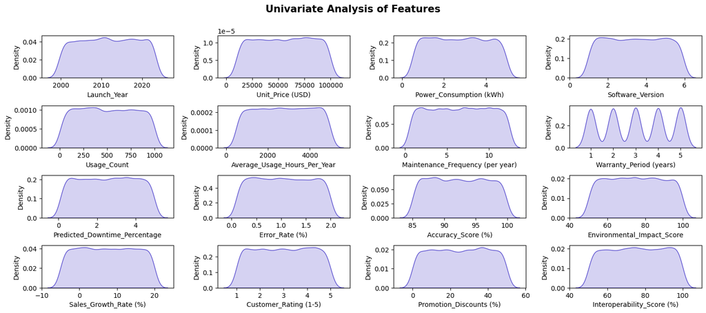

```python
plt.figure(figsize=(15,15))
plt.suptitle('Univariate Analysis of Features',fontweight='bold',fontsize=15,y=1)

for i in range(0,len(num_features)):
    plt.subplot(10,4,i+1)
    sns.kdeplot(x=df[num_features[i]],shade=True,color='#5A4FCF')
    plt.tight_layout()
```

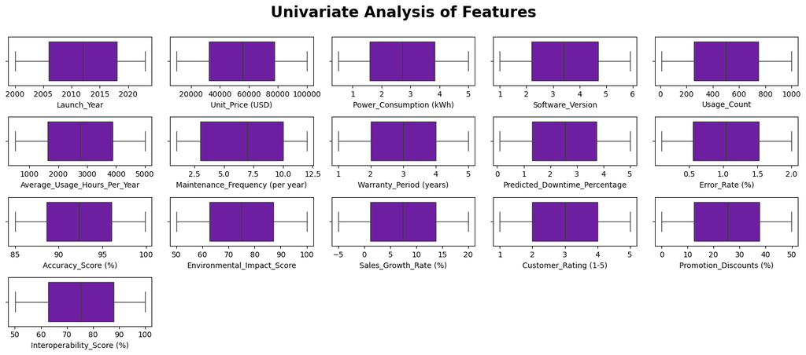

```python
plt.figure(figsize = (15,15))
plt.suptitle('Univariate Analysis of Features',fontweight='bold',fontsize=20,y=1)

for i in range(0,len(num_features)):
    plt.subplot(10,5,i+1)
    sns.boxplot(data=df,x=num_features[i],color='#7209B7')
    plt.xlabel(num_features[i])
    plt.tight_layout()
```

### Feature Engineering

```python
def replace_nan_with_mode(df, column_name):
    mode_value = df[column_name].mode()[0]  # Get the mode of the column
    df[column_name].fillna(mode_value, inplace=True)  # Replace NaN values with the mode

# Example usage
replace_nan_with_mode(df, 'Regulatory_Compliance')
replace_nan_with_mode(df, 'Smart_Features')
replace_nan_with_mode(df, 'Connectivity_Options')
```

```python
# Define mappings based on unique values
category_mapping = {value: idx for idx, value in enumerate(df['Category'].unique(), start=1)}
device_type_mapping = {value: idx for idx, value in enumerate(df['Device_Type'].unique(), start=1)}
model_name_mapping = {value: idx for idx, value in enumerate(df['Model_Name'].unique(), start=1)}
smart_features_mapping = {value: idx for idx, value in enumerate(df['Smart_Features'].unique(), start=0)}

# Apply mappings to the respective columns
df['Category'] = df['Category'].map(category_mapping)
df['Device_Type'] = df['Device_Type'].map(device_type_mapping)
df['Model_Name'] = df['Model_Name'].map(model_name_mapping)
df['Smart_Features'] = df['Smart_Features'].map(smart_features_mapping)
```

```python
import re

# Function to extract numeric points from the 'Specifications' column
def extract_points(value):
    if isinstance(value, str):  # Ensure the value is a string
        match = re.search(r'\d+', value)  # Extract the first numeric value
        if match:
            return int(match.group())  # Convert the extracted value to integer
    return None  # Return None if no numeric value is found

# Apply the extraction function to the 'Specifications' column
df['Specifications'] = df['Specifications'].apply(extract_points)
```

### Predicting Unit Price of Medical Devices

```python
from sklearn.model_selection import train_test_split
from sklearn.ensemble import RandomForestRegressor
from sklearn.metrics import mean_absolute_error, mean_squared_error, r2_score
```

```python
# Select features and target variable
X = df[['Category', 'Device_Type', 'Launch_Year', 'Power_Consumption (kWh)', 'Customer_Rating (1-5)', 'Model_Name', 'Specifications']]
y = df['Unit_Price (USD)']
```

```python
'''
from sklearn.preprocessing import OneHotEncoder
from sklearn.compose import ColumnTransformer

# Identify categorical columns for encoding
categorical_columns = ['Category', 'Device_Type', 'Model_Name', 'Specifications']

# Set up the OneHotEncoder
one_hot_encoder = OneHotEncoder(drop='first', sparse_output=False)

# Create a ColumnTransformer to apply the encoder
preprocessor = ColumnTransformer(
    transformers=[
        ('onehot', one_hot_encoder, categorical_columns)
    ],
    remainder='passthrough'  # Keep the other (non-categorical) columns as they are
)

# Apply the transformation
X_encoded = preprocessor.fit_transform(X)

# Convert the result back into a DataFrame for convenience
encoded_feature_names = preprocessor.get_feature_names_out()
X_encoded_df = pd.DataFrame(X_encoded, columns=encoded_feature_names)

# Train-test split
X_train, X_test, y_train, y_test = train_test_split(X_encoded_df, y, test_size=0.2, random_state=42)
'''
```

```python
# Encode categorical variables
# X = pd.get_dummies(X, columns=['Category', 'Device_Type', 'Model_Name', 'Specifications', 'Smart_Features'], drop_first=True)
```

```python
# Train-test split
X_train, X_test, y_train, y_test = train_test_split(X, y, test_size=0.2, random_state=42)
```

```python
# Model training
model = RandomForestRegressor(n_estimators=100, random_state=42, n_jobs=-1)
model.fit(X_train, y_train)
```

```
RandomForestRegressor(n_jobs=-1, random_state=42)
```

```python
# Predictions and evaluation
y_pred = model.predict(X_test)
print("MAE:", mean_absolute_error(y_test, y_pred))
print("RMSE:", mean_squared_error(y_test, y_pred, squared=False))
print("R2 Score:", r2_score(y_test, y_pred))
```

```
MAE: 22708.47364435
RMSE: 26520.455208207193
R2 Score: -0.053227979964154404
```

```python
print('Enter the Medical Devices Details')

category = int(input('Enter the Category: '))
device_type = int(input('Enter the Device Type: '))
launch_year = int(input('Enter the Launch Year: '))
power_consumption = float(input('Enter the Power Consumption (kWh): '))
customer_rating  = float(input('Enter the Customer_Rating (1-5): '))
model_name = int(input('Enter the Model Name: '))
specifications = int(input('Enter the Specifications: '))

input_point = np.array([[category, device_type, launch_year, power_consumption, customer_rating, model_name, specifications]])

prediction = model.predict(input_point)

print(f'Your Medical Device: {prediction[0]} Unit Price')
```

```
Enter the Medical Devices Details
Enter the Category: 2
Enter the Device Type: 2
Enter the Launch Year: 2023
Enter the Power Consumption (kWh): 4.53
Enter the Customer_Rating (1-5): 3.8
Enter the Model Name: 2
Enter the Specifications: 60
Your Medical Device: 80908.98470000006 Unit Price
```

### Error Rate Prediction : Regression Problem

#### Approach:

- Define the target variable: Use Error_Rate as the target variable.
- Select features: Use relevant features like Power_Consumption (kWh), Maintenance_Frequency py, Software_Version, Model_Name, etc.
- Train-Test Split: Divide the data into training and testing sets.
- Model Selection: Use a regression model like Random Forest Regressor or XGBoost Regressor.
- Model Evaluation: Evaluate the model using metrics like Mean Squared Error (MSE), R-Squared, etc.

```python
from sklearn.model_selection import train_test_split
from sklearn.ensemble import RandomForestRegressor
from sklearn.metrics import mean_squared_error, r2_score
```

```python
# Define Features and Target
features = ['Category', 'Device_Type', 'Model_Name', 'Launch_Year', 'Power_Consumption (kWh)', 'Software_Version', 'Maintenance_Frequency (per year)']
target = 'Error_Rate (%)'

X = df[features]
y = df[target]
```

```python
# Split the data into training and testing sets
X_train, X_test, y_train, y_test = train_test_split(X, y, test_size=0.2, random_state=42)
```

```python
# Initialize the Random Forest Regressor
model = RandomForestRegressor(n_estimators=100, random_state=42)
```

```python
# Train the model
model.fit(X_train, y_train)
```

```
RandomForestRegressor(random_state=42)
```

```python
# Make predictions
y_pred = model.predict(X_test)

# Evaluate the model
mse = mean_squared_error(y_test, y_pred)
r2 = r2_score(y_test, y_pred)

print(f"Mean Squared Error: {mse}")
print(f"R-Squared: {r2}")
```

```
Mean Squared Error: 0.32077127537
R-Squared: -0.05656931574145596
```

```python
# Feature Importance
importance = model.feature_importances_
for i, feature in enumerate(features):
    print(f"Feature: {feature}, Importance: {importance[i]}")
```

```
Feature: Category, Importance: 0.04302767688371752
Feature: Device_Type, Importance: 0.08112907865493016
Feature: Model_Name, Importance: 0.24702807981065014
Feature: Launch_Year, Importance: 0.1366309273124931
Feature: Power_Consumption (kWh), Importance: 0.22122079327767033
Feature: Software_Version, Importance: 0.16186724674524966
Feature: Maintenance_Frequency (per year), Importance: 0.10909619731528902
```

```python
# Feature Selection with Recursive Feature Elimination (RFE)
# Use techniques like Recursive Feature Elimination (RFE) to find the most important features for predicting Error_Rate.

from sklearn.feature_selection import RFE

# Initialize the model
rf = RandomForestRegressor(random_state=42)

# Perform Recursive Feature Elimination
rfe = RFE(estimator=rf, n_features_to_select=5)
rfe.fit(X, y)

# Selected features
selected_features = [features[i] for i in range(len(features)) if rfe.support_[i]]
print(f"Selected Features: {selected_features}")

# Update X with selected features
X_selected = df[selected_features]
```

```
Selected Features: ['Model_Name', 'Launch_Year', 'Power_Consumption (kWh)', 'Software_Version', 'Maintenance_Frequency (per year)']
```

```python
# Hyperparameter Tuning with GridSearchCV
# Optimize the Random Forest model for better performance.

from sklearn.model_selection import GridSearchCV

# Define parameter grid
param_grid = {
    'n_estimators': [50, 100, 200],
    'max_depth': [10, 20, None],
    'min_samples_split': [2, 5, 10],
    'min_samples_leaf': [1, 2, 4]
}

# Initialize GridSearchCV
grid_search = GridSearchCV(estimator=rf, param_grid=param_grid, cv=5, scoring='r2', verbose=1, n_jobs=-1)

# Fit the model
grid_search.fit(X_selected, y)

# Best parameters and score
print(f"Best Parameters: {grid_search.best_params_}")
print(f"Best R2 Score: {grid_search.best_score_}")

# Use the best model for predictions
best_model = grid_search.best_estimator_
```

```
Fitting 5 folds for each of 81 candidates, totalling 405 fits
Best Parameters: {'max_depth': 10, 'min_samples_leaf': 1, 'min_samples_split': 10, 'n_estimators': 200}
Best R2 Score: -0.00813066603964967
```

```python
# Advanced Modeling: Gradient Boosting with XGBoost
# Use a more advanced boosting algorithm for better prediction performance.

from xgboost import XGBRegressor

# Initialize XGBoost model
xgb_model = XGBRegressor(objective='reg:squarederror', random_state=42)

# Train the model
xgb_model.fit(X_selected, y)

# Predict on the test set
y_pred_xgb = xgb_model.predict(X_test[selected_features])

# Evaluate the model
mse_xgb = mean_squared_error(y_test, y_pred_xgb)
r2_xgb = r2_score(y_test, y_pred_xgb)

print(f"XGBoost Mean Squared Error: {mse_xgb}")
print(f"XGBoost R-Squared: {r2_xgb}")
```

```
XGBoost Mean Squared Error: 0.14684660769181812
XGBoost R-Squared: 0.5163107431333018
```

```
100%|===================| 9995/10000 [01:26<00:00]
```

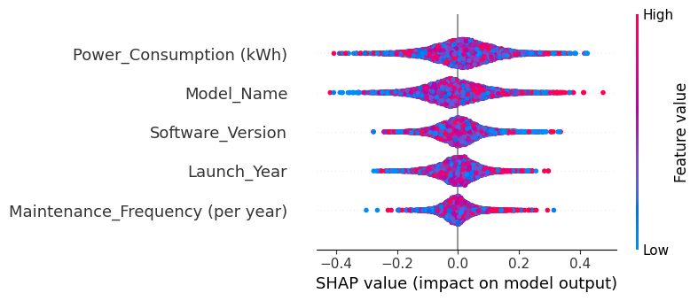

```python
# Explainability: SHAP for Feature Importance
# Use SHAP to interpret the model and understand how features contribute to predictions.

import shap

# Initialize SHAP explainer
explainer = shap.Explainer(xgb_model, X_selected)
shap_values = explainer(X_selected)

# Plot feature importance
shap.summary_plot(shap_values, X_selected)
```

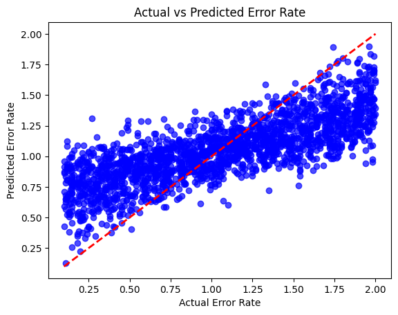

```python
# Visualizing Predictions
# Visualize the predicted vs actual Error_Rate values to analyze model performance.

# Plot actual vs predicted
plt.scatter(y_test, y_pred_xgb, alpha=0.7, color='blue')
plt.plot([y_test.min(), y_test.max()], [y_test.min(), y_test.max()], 'k--', color='red', lw=2)
plt.xlabel('Actual Error Rate')
plt.ylabel('Predicted Error Rate')
plt.title('Actual vs Predicted Error Rate')
plt.show()
```

```python
# Ensemble Approach: Combining Models
# Combine predictions from multiple models (e.g., Random Forest and XGBoost) using an ensemble method like averaging.

# Ensemble predictions
ensemble_pred = (y_pred + y_pred_xgb) / 2

# Evaluate ensemble
mse_ensemble = mean_squared_error(y_test, ensemble_pred)
r2_ensemble = r2_score(y_test, ensemble_pred)

print(f"Ensemble Mean Squared Error: {mse_ensemble}")
print(f"Ensemble R-Squared: {r2_ensemble}")
```

```
Ensemble Mean Squared Error: 0.21634520407390562
Ensemble R-Squared: 0.2873934738431685
```

```python
from xgboost import XGBRegressor
from sklearn.metrics import mean_squared_error, mean_absolute_error, r2_score
import numpy as np

# Initialize and train the regression model
model = XGBRegressor()
model.fit(X_train, y_train)

# Predict on test data
y_pred = model.predict(X_test)

# Calculate evaluation metrics
mse = mean_squared_error(y_test, y_pred)
mae = mean_absolute_error(y_test, y_pred)
r2 = r2_score(y_test, y_pred)

# Print the metrics
print('Mean Squared Error:', mse)
print('Mean Absolute Error:', mae)
print('R-squared:', r2)
```

```
Mean Squared Error: 0.3605388139316142
Mean Absolute Error: 0.5094404269611835
R-squared: -0.18755723215729203
```

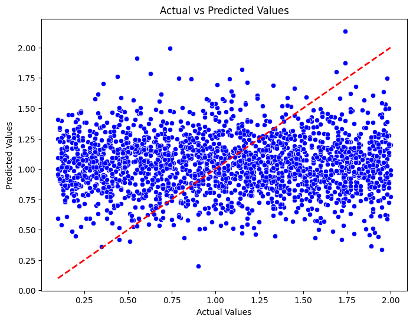

```python
# Scatter Plot of Actual vs. Predicted Values
# Create a scatter plot
plt.figure(figsize=(8, 6))
sns.scatterplot(x=y_test, y=y_pred, color='blue')

# Add a line for perfect predictions
plt.plot([y_test.min(), y_test.max()], [y_test.min(), y_test.max()], 'r--', lw=2)

# Title and labels
plt.title('Actual vs Predicted Values')
plt.xlabel('Actual Values')
plt.ylabel('Predicted Values')

# Show the plot
plt.show()
```

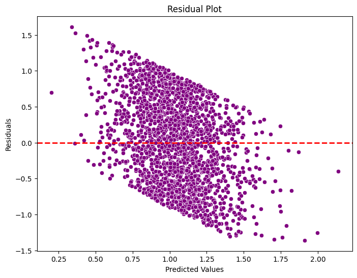

```python
# Residual Plot
# Calculate residuals
residuals = y_test - y_pred

# Create a residual plot
plt.figure(figsize=(8, 6))
sns.scatterplot(x=y_pred, y=residuals, color='purple')

# Add a horizontal line at 0
plt.axhline(y=0, color='r', linestyle='--', lw=2)

# Title and labels
plt.title('Residual Plot')
plt.xlabel('Predicted Values')
plt.ylabel('Residuals')

# Show the plot
plt.show()
```

```
Mean Squared Error (MSE): 0.3754277990822035
R-squared (R²): -0.2365991697014107
```

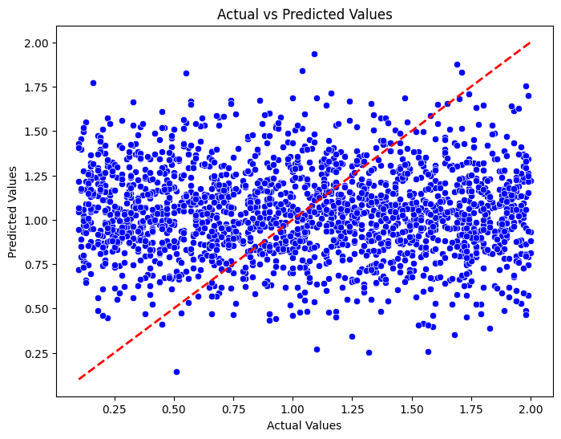

```python
# Initialize the model
model_2 = XGBRegressor(n_estimators=1500, learning_rate=0.05, n_jobs=4)

# Fit the model with early stopping
model_2.fit(
    X_train, y_train,
    eval_set=[(X_test, y_test)],
    verbose=False
)

# Predictions
y_pred_2 = model_2.predict(X_test)

# Evaluate performance
mse_2 = mean_squared_error(y_test, y_pred_2)
r2_2 = r2_score(y_test, y_pred_2)

print("Mean Squared Error (MSE):", mse_2)
print("R-squared (R²):", r2_2)

# Visualization: Actual vs Predicted Values
plt.figure(figsize=(8, 6))
sns.scatterplot(x=y_test, y=y_pred_2, color='blue')
plt.plot([y_test.min(), y_test.max()], [y_test.min(), y_test.max()], 'r--', lw=2)
plt.title('Actual vs Predicted Values')
plt.xlabel('Actual Values')
plt.ylabel('Predicted Values')
plt.show()
```

```python
# Split the data into training and testing sets
X_train, X_test, y_train, y_test = train_test_split(X, y, test_size=0.2, random_state=42)

# Train an XGBRegressor with default hyperparameters
model = XGBRegressor(n_estimators=1500, learning_rate=0.05, n_jobs=4)
model.fit(X_train, y_train)

# Evaluate the model on the training set
train_preds = model.predict(X_train)
train_mse = mean_squared_error(y_train, train_preds)
train_r2 = r2_score(y_train, train_preds)

# Evaluate the model on the testing set
test_preds = model.predict(X_test)
test_mse = mean_squared_error(y_test, test_preds)
test_r2 = r2_score(y_test, test_preds)

print(f"Training MSE: {train_mse:.2f}")
print(f"Training R²: {train_r2:.2f}")
print(f"Testing MSE: {test_mse:.2f}")
print(f"Testing R²: {test_r2:.2f}")
```

```
Training MSE: 0.04
Training R²: 0.88
Testing MSE: 0.38
Testing R²: -0.24
```

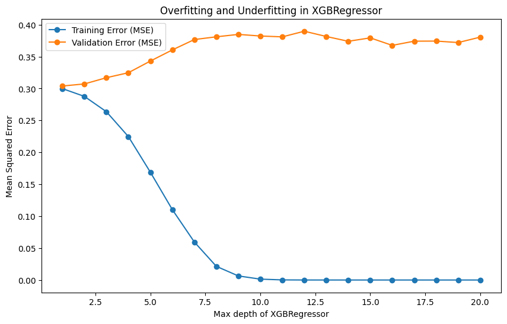

```python
# Splitting the dataset
X_train, X_test, y_train, y_test = train_test_split(X, y, test_size=0.2, random_state=42)

# Function to plot overfitting and underfitting
def plot_overfitting_underfitting(X_train, y_train, X_test, y_test):
    train_errors = []
    test_errors = []
    max_depths = list(range(1, 21))

    for max_depth in max_depths:
        model = XGBRegressor(max_depth=max_depth, random_state=42)
        model.fit(X_train, y_train)

        # Predictions
        y_train_pred = model.predict(X_train)
        y_test_pred = model.predict(X_test)

        # Calculate errors (MSE)
        train_errors.append(mean_squared_error(y_train, y_train_pred))
        test_errors.append(mean_squared_error(y_test, y_test_pred))

    # Plotting the errors
    plt.figure(figsize=(10, 6))
    plt.plot(max_depths, train_errors, label='Training Error (MSE)', marker='o')
    plt.plot(max_depths, test_errors, label='Validation Error (MSE)', marker='o')
    plt.xlabel('Max depth of XGBRegressor')
    plt.ylabel('Mean Squared Error')
    plt.title('Overfitting and Underfitting in XGBRegressor')
    plt.legend()
    plt.show()

# Plotting
plot_overfitting_underfitting(X_train, y_train, X_test, y_test)
```

```python
import xgboost as xgb
from sklearn.model_selection import GridSearchCV
from sklearn.metrics import mean_squared_error, r2_score

# Define the model
xgb_model = xgb.XGBRegressor(objective='reg:squarederror')

# Define the parameter grid
param_grid = {
    'eta': [0.01, 0.03, 0.1],
    'max_depth': [3, 5, 7],
    'min_child_weight': [1, 3, 5],
    'gamma': [0, 0.1, 0.3],
    'subsample': [0.7, 0.8, 0.9],
    'colsample_bytree': [0.7, 0.8, 0.9]
}

# Perform Grid Search
grid_search = GridSearchCV(estimator=xgb_model, param_grid=param_grid, scoring='neg_mean_squared_error', cv=3, verbose=1, n_jobs=-1)
grid_search.fit(X_train, y_train)

# Best parameters and model
best_params = grid_search.best_params_
best_model = grid_search.best_estimator_

print(f"Best parameters: {best_params}")

# Predict on the test data
y_pred = best_model.predict(X_test)

# Calculate and display the metrics
mse = mean_squared_error(y_test, y_pred)
r2 = r2_score(y_test, y_pred)

print(f"Mean Squared Error: {mse}")
print(f"R² Score: {r2}")
```

```
Fitting 3 folds for each of 729 candidates, totalling 2187 fits
Best parameters: {'colsample_bytree': 0.8, 'eta': 0.01, 'gamma': 0.3, 'max_depth': 3, 'min_child_weight': 1, 'subsample': 0.8}
Mean Squared Error: 0.30373586130947083
R² Score: -0.0004573844080026923
```

```python
from sklearn.preprocessing import StandardScaler
scaler = StandardScaler()
X_train = scaler.fit_transform(X_train)
X_test = scaler.fit_transform(X_test)
```

```python
# Define the base model
base_model = XGBRegressor(n_estimators=1500, learning_rate=0.05, n_jobs=4)
base_model.fit(X_train, y_train)

# Evaluate the model on the training set
train_preds = base_model.predict(X_train)
train_mse = mean_squared_error(y_train, train_preds)
train_r2 = r2_score(y_train, train_preds)

# Evaluate the model on the testing set
test_preds = base_model.predict(X_test)
test_mse = mean_squared_error(y_test, test_preds)
test_r2 = r2_score(y_test, test_preds)

# Print the evaluation metrics
print(f"Training Mean Squared Error: {train_mse:.2f}")
print(f"Training R² Score: {train_r2:.2f}")
print(f"Testing Mean Squared Error: {test_mse:.2f}")
print(f"Testing R² Score: {test_r2:.2f}")
```

```
Training Mean Squared Error: 0.04
Training R² Score: 0.88
Testing Mean Squared Error: 0.36
Testing R² Score: -0.20
```

```python
# XGBoost model instance
xgb_model = xgb.XGBRegressor(objective='reg:squarederror', random_state=42)

# Hyperparameter tuning with GridSearchCV
param_grid = {
    'n_estimators': [100, 200, 300],
    'max_depth': [3, 5, 7],
    'learning_rate': [0.01, 0.05, 0.1],
    'subsample': [0.8, 0.9, 1.0],
    'colsample_bytree': [0.8, 0.9, 1.0]
}

grid_search = GridSearchCV(estimator=xgb_model, param_grid=param_grid, scoring='r2', cv=3, verbose=1, n_jobs=-1)
grid_search.fit(X_train, y_train)

# Best parameters
best_params = grid_search.best_params_
print("Best parameters:", best_params)

# Train the model with the best parameters
best_xgb_model = xgb.XGBRegressor(**best_params, objective='reg:squarederror', random_state=42)
best_xgb_model.fit(X_train, y_train)

# Evaluate on training and testing sets
y_train_pred = best_xgb_model.predict(X_train)
y_test_pred = best_xgb_model.predict(X_test)

# Calculate performance metrics
train_rmse = np.sqrt(mean_squared_error(y_train, y_train_pred))
test_rmse = np.sqrt(mean_squared_error(y_test, y_test_pred))

train_r2 = r2_score(y_train, y_train_pred)
test_r2 = r2_score(y_test, y_test_pred)

print(f"Training RMSE: {train_rmse}, R2: {train_r2}")
print(f"Testing RMSE: {test_rmse}, R2: {test_r2}")

# Check for underfitting and overfitting
if train_r2 > test_r2 + 0.1:
    print("The model might be overfitting.")
elif test_r2 > train_r2 + 0.1:
    print("The model might be underfitting.")
else:
    print("The model is performing well.")
```

```
Fitting 3 folds for each of 243 candidates, totalling 729 fits
Best parameters: {'colsample_bytree': 0.8, 'learning_rate': 0.01, 'max_depth': 3, 'n_estimators': 100, 'subsample': 0.9}
Training RMSE: 0.5477019797424676, R2: 0.00835533422232948
Testing RMSE: 0.5514369384047372, R2: -0.0015998058641886193
The model is performing well.
```

```
Fitting 3 folds for each of 2187 candidates, totalling 6561 fits
Best Hyperparameters:
{'colsample_bytree': 1.0, 'gamma': 0, 'learning_rate': 0.01, 'max_depth': 3, 'min_child_weight': 3, 'n_estimators': 50, 'subsample': 0.8}

Training RMSE: 0.55, R2: 0.01
Testing RMSE: 0.55, R2: -0.00
The model is performing well.
```

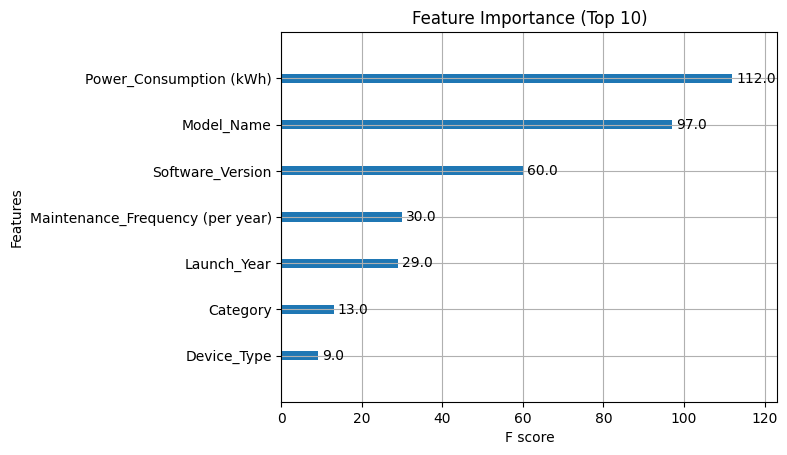

```python
# Define Features and Target
features = ['Category', 'Device_Type', 'Model_Name', 'Launch_Year', 'Power_Consumption (kWh)',
            'Software_Version', 'Maintenance_Frequency (per year)']
target = 'Error_Rate (%)'

X = df[features]
y = df[target]


# Train-Test Split
X_train, X_test, y_train, y_test = train_test_split(X, y, test_size=0.2, random_state=42)

# Define XGBoost Model
xgb_model = xgb.XGBRegressor(objective='reg:squarederror', random_state=42)

# Define Hyperparameter Grid
param_grid = {
    'n_estimators': [50, 100, 200],
    'max_depth': [3, 5, 7],
    'learning_rate': [0.01, 0.1, 0.2],
    'subsample': [0.6, 0.8, 1.0],
    'colsample_bytree': [0.6, 0.8, 1.0],
    'gamma': [0, 1, 5],
    'min_child_weight': [1, 3, 5]
}

# Hyperparameter Tuning with GridSearchCV
grid_search = GridSearchCV(estimator=xgb_model, param_grid=param_grid,
                           scoring='neg_mean_squared_error', cv=3, verbose=1, n_jobs=-1)
grid_search.fit(X_train, y_train)

# Extract Best Parameters
best_params = grid_search.best_params_
print("Best Hyperparameters:")
print(best_params)

# Train Final Model
best_xgb_model = xgb.XGBRegressor(**best_params, objective='reg:squarederror', random_state=42)
best_xgb_model.fit(X_train, y_train)

# Predictions and Performance Metrics
y_train_pred = best_xgb_model.predict(X_train)
y_test_pred = best_xgb_model.predict(X_test)

# Calculate RMSE and R2 for both train and test sets
train_rmse = np.sqrt(mean_squared_error(y_train, y_train_pred))
test_rmse = np.sqrt(mean_squared_error(y_test, y_test_pred))

train_r2 = r2_score(y_train, y_train_pred)
test_r2 = r2_score(y_test, y_test_pred)

print(f"\nTraining RMSE: {train_rmse:.2f}, R2: {train_r2:.2f}")
print(f"Testing RMSE: {test_rmse:.2f}, R2: {test_r2:.2f}")

# Evaluate Underfitting and Overfitting
if train_r2 > test_r2 + 0.1:
    print("The model is overfitting. Consider regularization or tuning.")
elif test_r2 > train_r2 + 0.1:
    print("The model is underfitting. Increase model complexity.")
else:
    print("The model is performing well.")

# Feature Importance
plt.figure(figsize=(10, 6))
xgb.plot_importance(best_xgb_model, importance_type='weight', max_num_features=10)
plt.title("Feature Importance (Top 10)")
plt.show()
```

```python
import pickle

pickle.dump(best_xgb_model,open('error_rate_model.pkl','wb'))

x_model = pickle.load(open('error_rate_model.pkl','rb'))
```

```python
print('Error Rate Prediction')

category = int(input('Enter the Category: '))
device_type = int(input('Enter the Device Type: '))
model_name = int(input('Enter the Model Type Name: '))
launch_year = int(input('Enter the Launch Year: '))
power_consumption = float(input('Enter the Power Consumption (kWh): '))
software_version  = float(input('Enter the Software Version: '))
maintenance_frequency_py = int(input('Enter the Maintenance_Frequency (per year): '))

input_point = np.array([[category, device_type, model_name, launch_year, power_consumption, software_version, maintenance_frequency_py]])

prediction = x_model.predict(input_point)

print(f'Error Rate: {prediction[0]} Predicte')
```

```
Error Rate Prediction
Enter the Category: 2
Enter the Device Type: 2
Enter the Model Type Name: 2
Enter the Launch Year: 2023
Enter the Power Consumption (kWh): 4.53
Enter the Software Version: 3.3
Enter the Maintenance_Frequency (per year): 10
Error Rate: 1.0457432270050049 Predicte
```

```python
# More Advance Working Sonn..!
# Notebook Project By : PRASAD JADHAV (ML-ENG)
# LinkedIn: linkedin.com/in/prasadmjadhav2 | Github: github.com/prasadmjadhav2 | Mail: prasadmjadhav6161@gmail.com
```